# Google Capstone Project

Kingsley Yeboah Kwarteng

January 4, 2024

# Ask

The project delineates the inquiries posed to the Cyclystics data and establishes the context in which these questions are explored below.

As a junior data analyst within the marketing analyst team at Cyclistic, a bike-share company in Chicago, your role is crucial. The marketing director holds the belief that the future success of the company hinges on optimizing the number of annual memberships. Consequently, your team aims to gain a comprehensive understanding of the distinct usage patterns of Cyclistic bikes by casual riders and annual members. Armed with these insights, your team intends to formulate a new marketing strategy aimed at enticing casual riders to transition into becoming annual members. However, the approval of these recommendations by Cyclistic executives is contingent on robust data insights and professional data visualizations that substantiate your proposals.

1.How do annual members and casual riders use Cyclistic bikes differently? 2.Why would casual riders buy Cyclistic annual memberships? 3.How can Cyclistic use digital media to influence casual riders to become members?

# Prepare

The objective of this part of the project is to outline how we get the data ready for analysis.

# Download

# Store

The zip files were stored initially on my laptops hard drive.

# Process

This is where the real excitement began. In this phase, my focus was on eliminating any inconsistencies, ensuring meticulous data cleaning, and incorporating relevant calculations. The initial steps of processing and cleaning were carried out using R.

## Loading the libraries I will be needing to complete this project

```r
library(tidyverse)
```

```r
library(dplyr)
library(ggplot2)
library(lubridate)
library(readxl)
```

# Data Collection

At the core of data analysis lies the crucial process of acquiring precise and pertinent information. The chosen dataset spans multiple quarters, presenting a holistic view of the topic at hand. The data was meticulously gathered from the publicly accessible Divvy Trips dataset (https://divvy-tripdata.s3.amazonaws.com/index.html), offering intricate trip logs with diverse parameters including start and end times, station names, and rider classifications. To ensure a thorough understanding, a compilation of quarterly datasets was obtained from (https://www.kaggle.com/datasets/evangower/cyclistic-bike-share).

## Loading and Preprocessing Data

```r
#Reading the contents of a CSV file and saving them into a variable named tripdata.

tripdata1 <- read_csv("R Documents/capstone2023/tripdata1.csv")
tripdata2 <- read_csv("R Documents/capstone2023/tripdata2.csv")
tripdata3 <- read_csv("R Documents/capstone2023/tripdata3.csv")
tripdata4 <- read_csv("R Documents/capstone2023/tripdata4.csv")
tripdata5 <- read_csv("R Documents/capstone2023/tripdata5.csv")
tripdata6 <- read_csv("R Documents/capstone2023/tripdata6.csv")
tripdata7 <- read_csv("R Documents/capstone2023/tripdata7.csv")
tripdata8 <- read_csv("R Documents/capstone2023/tripdata8.csv")
tripdata9 <- read_csv("R Documents/capstone2023/tripdata9.csv")
tripdata10 <- read_csv("R Documents/capstone2023/tripdata10.csv")
tripdata11<- read_csv("R Documents/capstone2023/tripdata11.csv")
tripdata12<- read_csv("R Documents/capstone2023/tripdata12.csv")
```

# Combining all Data Frames into a Unified Data Frame

With all CSV files successfully loaded into their individual data frames, we can enhance the efficiency of our analysis by amalgamating them into a comprehensive data frame.

```r
# Merging individual data frames into one
tripdata <- bind_rows(tripdata1,tripdata2,tripdata3,tripdata4,tripdata5,tripdata6,tripdata7,
                      tripdata8,tripdata9,tripdata10,tripdata11,tripdata12)

# Checking the structure of the merged data
str(tripdata)
```

```
## spc_tbl_ [5,677,610 × 13] (S3: spec_tbl_df/tbl_df/tbl/data.frame)
##  $ ride_id           : chr [1:5677610] "65DBD2F447EC51C2" "0C201AA7EA0EA1AD" "E0B148CCB358A49D" "54C5775D2B7C9188" ...
##  $ rideable_type     : chr [1:5677610] "electric_bike" "classic_bike" "electric_bike" "classic_bike" ...
##  $ started_at        : POSIXct[1:5677610], format: "2022-12-05 10:47:18" "2022-12-18 06:42:33" ...
##  $ ended_at          : POSIXct[1:5677610], format: "2022-12-05 10:56:34" "2022-12-18 07:08:44" ...
##  $ start_station_name: chr [1:5677610] "Clifton Ave & Armitage Ave" "Broadway & Belmont Ave" "Sangamon St & Lake St" "Shields Ave & 31st St" ...
##  $ start_station_id  : chr [1:5677610] "TA1307000163" "13277" "TA1306000015" "KA1503000038" ...
##  $ end_station_name  : chr [1:5677610] "Sedgwick St & Webster Ave" "Sedgwick St & Webster Ave" "St. Clair St & Erie St" "Damen Ave & Madison St" ...
##  $ end_station_id    : chr [1:5677610] "13191" "13191" "13016" "13134" ...
##  $ start_lat         : num [1:5677610] 41.9 41.9 41.9 41.8 41.9 ...
##  $ start_lng         : num [1:5677610] -87.7 -87.6 -87.7 -87.6 -87.7 ...
##  $ end_lat           : num [1:5677610] 41.9 41.9 41.9 41.9 41.9 ...
##  $ end_lng           : num [1:5677610] -87.6 -87.6 -87.6 -87.7 -87.7 ...
##  $ member_casual     : chr [1:5677610] "member" "casual" "member" "member" ...
##  - attr(*, "spec")=
##   .. cols(
##   ..   ride_id = col_character(),
##   ..   rideable_type = col_character(),
##   ..   started_at = col_datetime(format = ""),
##   ..   ended_at = col_datetime(format = ""),
##   ..   start_station_name = col_character(),
##   ..   start_station_id = col_character(),
##   ..   end_station_name = col_character(),
##   ..   end_station_id = col_character(),
##   ..   start_lat = col_double(),
##   ..   start_lng = col_double(),
##   ..   end_lat = col_double(),
##   ..   end_lng = col_double(),
##   ..   member_casual = col_character()
##   .. )
##  - attr(*, "problems")=<externalptr>
```

# Data Cleaning

## Eliminated Rows With Missing Values

As part of my assumptions, I considered any trip lacking a start or end station as an error, prompting the removal of such entries from the dataset. Additionally, I identified and removed blank rows associated with coordinates to ensure data integrity.

```r
#dropping N/A trips
no_blank_trips <- drop_na(tripdata)
```

```r
# Calculate trip duration in seconds
no_blank_trips$trip_duration <- as.numeric(difftime(no_blank_trips$ended_at, no_blank_trips$started_at, units = "min"))

# Rounding trip durations to 2 decimal places
no_blank_trips$trip_duration <- round(no_blank_trips$trip_duration, digits = 2)
```

```r
# Filtering completed trips based on duration
completed_trips <- no_blank_trips[(no_blank_trips$trip_duration > 1 & no_blank_trips$trip_duration < 34560),]

# Using completed_trips as trips_summary
trips_summary <- completed_trips
```

## Inspecting the merged data

```r
summary(trips_summary)
```

```
##    ride_id          rideable_type        started_at
##  Length:4211929     Length:4211929     Min.   :2022-12-01 00:01:22.00
##  Class :character   Class :character   1st Qu.:2023-05-10 15:58:18.00
##  Mode  :character   Mode  :character   Median :2023-07-13 07:39:19.00
##                                        Mean   :2023-07-03 10:26:05.41
##                                        3rd Qu.:2023-09-07 12:20:56.00
##                                        Max.   :2023-11-30 23:58:38.00
##     ended_at                      start_station_name start_station_id
##  Min.   :2022-12-01 00:03:41.00   Length:4211929     Length:4211929
##  1st Qu.:2023-05-10 16:14:41.00   Class :character   Class :character
##  Median :2023-07-13 07:50:30.00   Mode  :character   Mode  :character
##  Mean   :2023-07-03 10:42:22.27
##  3rd Qu.:2023-09-07 12:36:59.00
##  Max.   :2023-12-01 09:47:35.00
##  end_station_name   end_station_id       start_lat       start_lng
##  Length:4211929     Length:4211929     Min.   :41.65   Min.   :-87.84
##  Class :character   Class :character   1st Qu.:41.88   1st Qu.:-87.66
##  Mode  :character   Mode  :character   Median :41.90   Median :-87.64
##                                        Mean   :41.90   Mean   :-87.64
##                                        3rd Qu.:41.93   3rd Qu.:-87.63
##                                        Max.   :42.06   Max.   :-87.53
##     end_lat         end_lng       member_casual      trip_duration
##  Min.   : 0.00   Min.   :-87.84   Length:4211929     Min.   :    1.02
##  1st Qu.:41.88   1st Qu.:-87.66   Class :character   1st Qu.:    5.85
##  Median :41.90   Median :-87.64   Mode  :character   Median :   10.02
##  Mean   :41.90   Mean   :-87.64                      Mean   :   16.28
##  3rd Qu.:41.93   3rd Qu.:-87.63                      3rd Qu.:   17.75
##  Max.   :42.06   Max.   :  0.00                      Max.   :12136.30
```

# Analysis

What was the summary info for trip duration

```r
# Summary information for trip duration
summary(trips_summary$trip_duration)
```

```
##     Min.  1st Qu.   Median     Mean  3rd Qu.     Max.
##     1.02     5.85    10.02    16.28    17.75 12136.30
```

Total number of rides based on membership type

```r
#Total number of rides based on memberahip type
members_trip_total <- data.frame(table(trips_summary$member_casual))

colnames(members_trip_total) <- c("Membership Type", "Number of Rides")

members_trip_total
```

```
##   Membership Type Number of Rides
## 1          casual         1499842
## 2          member         2712087
```

## Total Duration of Rides

What was the total duration of riders based on membership type

```r
members_trip_total_duration <- aggregate(trips_summary$trip_duration, list(trips_summary$member_casual), FUN = sum)

colnames(members_trip_total_duration) <- c("Membership Type", "Trip Duration (Minutes)")

members_trip_total_duration
```

```
##   Membership Type Trip Duration (Minutes)
## 1          casual                34982797
## 2          member                33592071
```

## Average Trip Duration

```r
# Average trip duration based on membership type
members_trip_mean <- aggregate(trips_summary$trip_duration, list(trips_summary$member_casual), FUN = mean)
colnames(members_trip_mean) <- c("Membership Type","Average Trip (minutes)")
members_trip_mean
```

```
##   Membership Type Average Trip (minutes)
## 1          casual               23.32432
## 2          member               12.38606
```

# Longest And Shortest Trip Duration

## Longest Trip

What are the longest and the shortest trip duration types based on membership types?

```r
# Longest trip duration based on membership type
members_trip_max <- aggregate(trips_summary$trip_duration, list(trips_summary$member_casual), FUN = max)
colnames(members_trip_max) <- c("Membership Type", "Longest Trip (minutes)")
members_trip_max
```

```
##   Membership Type Longest Trip (minutes)
## 1          casual               12136.30
## 2          member                1497.87
```

## Shortest Trip

```r
# Shortest trip duration based on membership type
members_trip_min <- aggregate(trips_summary$trip_duration, list(trips_summary$member_casual), FUN = min)
colnames(members_trip_min) <- c("Membership Type", "Shortest Trip (minutes)")
members_trip_min
```

```
##   Membership Type Shortest Trip (minutes)
## 1          casual                    1.02
## 2          member                    1.02
```

# Most Popular Week

## How popular certain weekdays are between Casual, Annual Members and Overall

Which day of the week experienced the highest overall popularity?

```r
# Calculate trip_day
trips_summary$trip_day <- lubridate::wday(trips_summary$started_at, label = TRUE)
```

```r
# Most popular day of the week overall
members_trip_weekday_popular <- data.frame(table(trips_summary$trip_day))
colnames(members_trip_weekday_popular) <- c("Weekday", "Frequency")
members_trip_weekday_popular
```

```
##   Weekday Frequency
## 1     Sun    545022
## 2     Mon    548282
## 3     Tue    617376
## 4     Wed    616188
## 5     Thu    637473
## 6     Fri    606853
## 7     Sat    640735
```

## Most Popular Day based on Membership Type

What was the most popular day based on Membership Type?

```r
# Most popular day based on membership type
members_trip_popular_days <- data.frame(table(trips_summary$member_casual, trips_summary$trip_day))
colnames(members_trip_popular_days) <- c("Membership Type","Weekday","Frequency")
members_trip_popular_days
```

```
##    Membership Type Weekday Frequency
## 1           casual     Sun    248627
## 2           member     Sun    296395
## 3           casual     Mon    172219
## 4           member     Mon    376063
## 5           casual     Tue    178722
## 6           member     Tue    438654
## 7           casual     Wed    178843
## 8           member     Wed    437345
## 9           casual     Thu    195912
## 10          member     Thu    441561
## 11          casual     Fri    222357
## 12          member     Fri    384496
## 13          casual     Sat    303162
## 14          member     Sat    337573
```

# Data Visualization

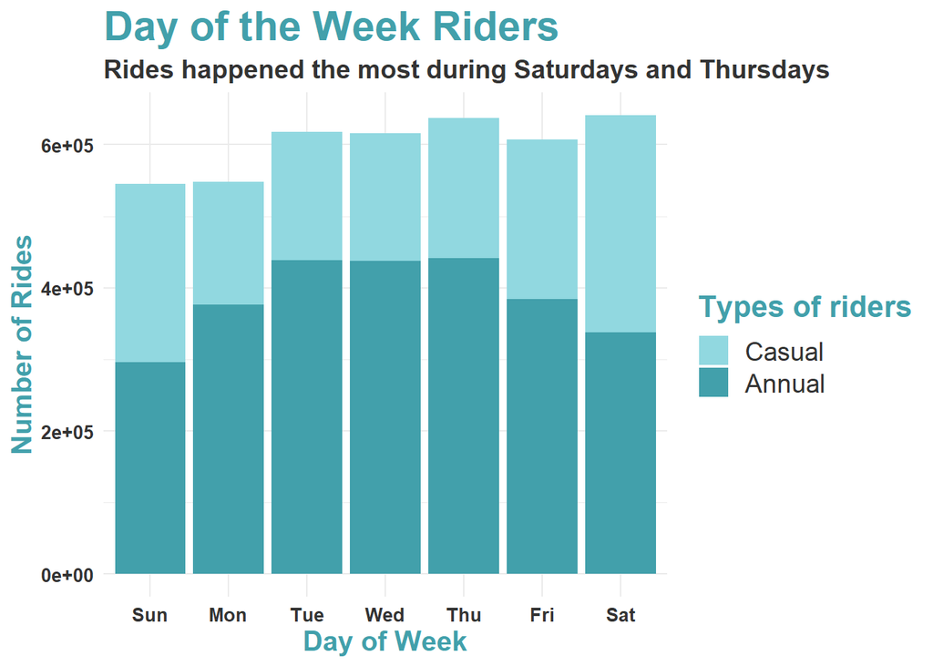

```r
# Data Visualization
ggplot(members_trip_popular_days, aes(x = `Weekday`, y = `Frequency`, fill = `Membership Type`)) +
 geom_bar(stat = "identity") +
  scale_fill_manual(values = c("#91d8e0", "#42a0ab"), name = "Types of riders", breaks = c("casual", "member"), labels = c("Casual", "Annual")) +
  labs(title = "Day of the Week Riders", subtitle = "Rides happened the most during Saturdays and Thursdays",

       x = "Day of Week", y = "Number of Rides") +
  theme_minimal() +
  theme(plot.title = element_text(size = 22, color = "#42a0ab", face = "bold"),
        plot.subtitle = element_text(size = 14, color = "grey20", face = "bold"),
        plot.caption = element_text(size = 8, color = "grey35"),
        legend.title = element_text(size = 16, face = "bold", color = "#42a0ab"),
        legend.text = element_text(size = 14, color = "grey20"),
        axis.title.x = element_text(size = 15, color = "#42a0ab", face = "bold"),
        axis.title.y = element_text(size = 15, color = "#42a0ab", face = "bold"),
        axis.text.x = element_text(size = 10, color = "grey20", face = "bold"),
        axis.text.y = element_text(size = 10, color = "grey20", face = "bold"))
```

## Key Results

```r
# Extracted the key results based on Membership Type
popular_casual_day <- members_trip_popular_days[members_trip_popular_days[, "Membership Type"] == "casual", ]
popular_member_day <- members_trip_popular_days[members_trip_popular_days[, "Membership Type"] == "member", ]

casual_most_popular_row <- which.max(popular_casual_day[, "Frequency"])
member_most_popular_row <- which.max(popular_member_day[, "Frequency"])

casual_most_popular_day <- popular_casual_day[casual_most_popular_row, c("Membership Type", "Weekday", "Frequency")]
member_most_popular_day <- popular_member_day[member_most_popular_row, c("Membership Type", "Weekday", "Frequency")]

most_popular_days <- rbind(casual_most_popular_day, member_most_popular_day)
most_popular_days
```

```
##    Membership Type Weekday Frequency
## 13          casual     Sat    303162
## 10          member     Thu    441561
```

## Most Popular Time period Overall

```r
# Calculate trip_time_period
completed_trips$trip_time_period <- cut(
  completed_trips$started_at,
  breaks = as.POSIXct(c("1970-01-01 00:00:00", "1970-01-01 06:00:00", "1970-01-01 12:00:00", "1970-01-01 18:00:00", "1970-01-02 00:00:00")),  # Adjust breaks as needed
  labels = c("Night", "Morning", "Afternoon", "Evening"),
  include.lowest = TRUE
)
```

```r
# Most popular time period overall
members_trip_popular_time_period <- data.frame(table(completed_trips$trip_time_period))
colnames(members_trip_popular_time_period) <- c("Time Period", "Frequency")
```

# Most popular time period based on Membership Type

```r
members_trip_popular_period <- data.frame(table(completed_trips$member_casual, completed_trips$trip_time_period))
colnames(members_trip_popular_period) <- c("Membership Type","Time Period","Frequency")
```

# Visualization of popular time periods

[figure not shown]

```r
ggplot(members_trip_popular_period, aes(x = `Time Period`, y = `Frequency`, fill = `Membership Type`)) +
  geom_col(position = "dodge") +
  geom_text(aes(label = `Frequency`), position = position_dodge(width = 0.9), vjust = -0.25) +
  scale_y_continuous(labels = scales::comma) +
  labs(x = "Time Period", y = "Frequency", fill = "Membership Type", title = "Most Popular Time Period by Membership Type") +
  theme_minimal()
```

## Most Popular Month Overall

Created the month column and calculated the most popular month

```r
# Extracting the month of the ride
trips_summary$month_of_ride <- format(trips_summary$started_at, "%B")

# Most popular month overall
members_trip_popular_month_overall <- data.frame(table(trips_summary$month_of_ride))
colnames(members_trip_popular_month_overall) <- c("Month", "Frequency")
members_trip_popular_month_overall
```

```
##        Month Frequency
## 1      April    314857
## 2     August    574384
## 3   December    132580
## 4   February    145817
## 5    January    144432
## 6       July    562749
## 7       June    524625
## 8      March    194503
## 9        May    452853
## 10  November    270148
## 11   October    396896
## 12 September    498085
```

# #Most Popular Month By Membership Type

```r
# Most popular month by membership type
members_trip_popular_month <- data.frame(table(trips_summary$member_casual, trips_summary$month_of_ride))
colnames(members_trip_popular_month) <- c("Membership Type","Month","Duration (Minutes)")
members_trip_popular_month
```

```
##    Membership Type     Month Duration (Minutes)
## 1           casual     April             108147
## 2           member     April             206710
## 3           casual    August             230150
## 4           member    August             344234
## 5           casual  December              30973
## 6           member  December             101607
## 7           casual  February              32138
## 8           member  February             113679
## 9           casual   January              29015
## 10          member   January             115417
## 11          casual      July             240849
## 12          member      July             321900
## 13          casual      June             215887
## 14          member      June             308738
## 15          casual     March              45730
## 16          member     March             148773
## 17          casual       May             173651
## 18          member       May             279202
## 19          casual  November              71059
## 20          member  November             199089
## 21          casual   October             128295
## 22          member   October             268601
## 23          casual September             193948
## 24          member September             304137
```

# Data Visualization for month

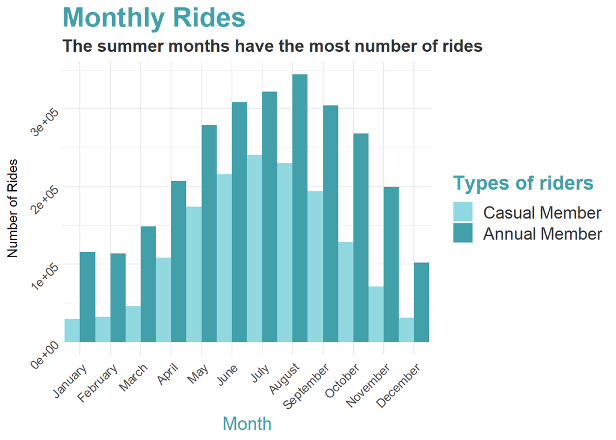

```r
# Data Visualization for Month
members_trip_popular_month$Month <- factor(members_trip_popular_month$Month, levels = month.name)


ggplot(members_trip_popular_month, aes(x = Month, y = `Duration (Minutes)`, fill = `Membership Type`)) +
  geom_bar(stat = "identity", position = "dodge", width = 1) +
  scale_fill_manual(values = c("#91d8e0", "#42a0ab"), name = "Types of riders", breaks = c("casual", "member"), labels = c("Casual Member", "Annual Member")) +
  labs(title = "Monthly Rides",
       subtitle = "The summer months have the most number of rides",
       x = "Month", y = "Number of Rides") +
  theme_minimal() +
  theme(
    axis.text.x = element_text(angle = 45, hjust = 1, size = 10),
    axis.text.y = element_text(angle = 45, hjust = 1, size = 10),
    plot.title = element_text(size = 22, color = "#42a0ab", face = "bold"),
    plot.subtitle = element_text(size = 14, color = "grey20", face = "bold"),
    plot.caption = element_text(size = 8, color = "grey35"),
    legend.title = element_text(size = 16, face = "bold", color = "#42a0ab"),
    legend.text = element_text(size = 14, color = "grey20"),
    axis.title.x = element_text(size = 15, color = "#42a0ab")
  )
```

# Extracting Key Results for Month

```r
# Extracted the key results based on Membership Type and Month
popular_casual_month <- members_trip_popular_month[members_trip_popular_month[, "Membership Type"] == "casual", ]
popular_member_month <- members_trip_popular_month[members_trip_popular_month[, "Membership Type"] == "member", ]

casual_most_popular_row2 <- which.max(popular_casual_month[, "Duration (Minutes)"])
member_most_popular_row2 <- which.max(popular_member_month[, "Duration (Minutes)"])

casual_most_popular_month <- popular_casual_month[casual_most_popular_row2, c("Membership Type", "Month", "Duration (Minutes)")]
member_most_popular_month<- popular_member_month[member_most_popular_row2, c("Membership Type", "Month", "Duration (Minutes)")]
most_popular_month <- rbind(casual_most_popular_month, member_most_popular_month)
most_popular_month
```

```
##    Membership Type  Month Duration (Minutes)
## 11          casual   July             240849
## 4           member August             344234
```

# Most Popular Bike Type Analysis

```r
# Most popular bike type by Membership Type
members_popular_bike <- data.frame(table(trips_summary$member_casual, trips_summary$rideable_type))
colnames(members_popular_bike) <- c("Membership Type","Bicycle Type","Number of rides")
members_popular_bike$`Number of rides` <- as.numeric(members_popular_bike$`Number of rides`)

members_popular_bike
```

```
##   Membership Type  Bicycle Type Number of rides
## 1          casual  classic_bike          852900
## 2          member  classic_bike         1765503
## 3          casual   docked_bike           77267
## 4          member   docked_bike               0
## 5          casual electric_bike          569675
## 6          member electric_bike          946584
```

# Vissualization

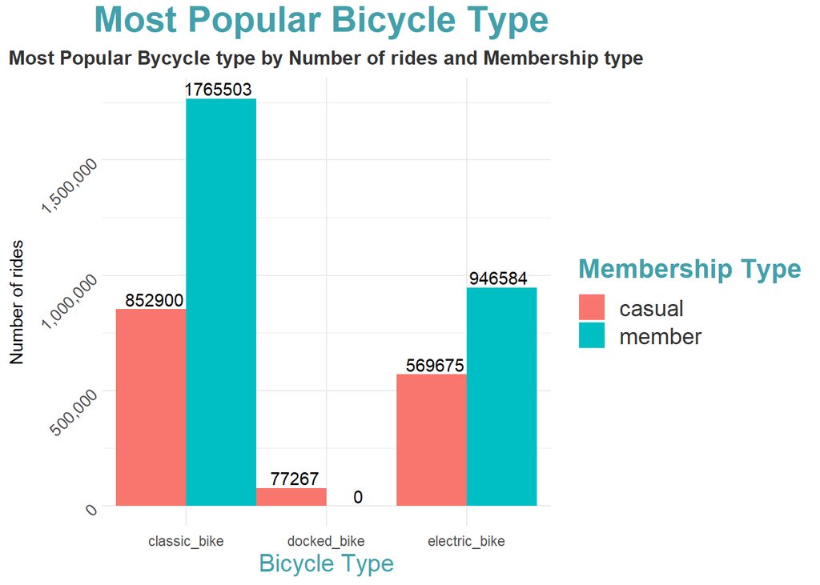

```r
# Visualization
ggplot(members_popular_bike, aes(x = `Bicycle Type`, y = `Number of rides`, fill = `Membership Type`))+
  geom_col(position = "dodge", width = 1)+
  geom_text(aes(label = `Number of rides`), position = position_dodge(width = 0.9), vjust = -0.25)+
  scale_y_continuous(labels = scales::comma) +
  labs(x = "Bicycle Type", y = "Number of rides", Fill = "Membership Type", title = "Most Popular Bicycle Type ", subtitle = "Most Popular Bycycle type by Number of rides and Membership type")+
  theme_minimal() +
  theme(
    axis.text.y = element_text(angle = 45, hjust = 1, size = 10),
    plot.title = element_text(size = 22, color = "#42a0ab",hjust = 0.5, vjust = 1.5, face = "bold"),
    plot.subtitle = element_text(size = 12, color = "grey20",hjust = 0.5, vjust = 1.5, face = "bold"),
    plot.caption = element_text(size = 8, color = "grey35"),
    legend.title = element_text(size = 16, face = "bold", color = "#42a0ab"),
    legend.text = element_text(size = 14, color = "grey20"),
    axis.title.x = element_text(size = 15, color = "#42a0ab")
  )
```

## Repeated the entire analysis again, but using Bicycle Type as the focus

```r
bicycle_trip_mean <- aggregate(trips_summary$trip_duration, list(trips_summary$rideable_type), FUN = mean)
colnames(bicycle_trip_mean) <- c("Bicycle Type","Average Trip (minutes)")
bicycle_trip_mean
```

```
##    Bicycle Type Average Trip (minutes)
## 1  classic_bike               17.39480
## 2   docked_bike               54.09850
## 3 electric_bike               12.43076
```

## Longest Tip by Bicycle Type

```r
bicycle_trip_max <- aggregate(trips_summary$trip_duration, list(trips_summary$rideable_type), FUN = max)
colnames(bicycle_trip_max) <- c("Bicycle Type", "Longest Trip (minutes)")
bicycle_trip_max
```

```
##    Bicycle Type Longest Trip (minutes)
## 1  classic_bike                1497.90
## 2   docked_bike               12136.30
## 3 electric_bike                 479.98
```

## Shortest trip by bicycle Type

```r
bicycle_trip_min <- aggregate(trips_summary$trip_duration, list(trips_summary$rideable_type), FUN = min)
colnames(bicycle_trip_min) <- c("Bicycle Type", "Shortest Trip (minutes)")
bicycle_trip_min
```

```
##    Bicycle Type Shortest Trip (minutes)
## 1  classic_bike                    1.02
## 2   docked_bike                    1.02
## 3 electric_bike                    1.02
```

## Most Popular Bicycle type

```r
members_trip_popular_bike <- data.frame(table(trips_summary$rideable_type))
colnames(members_trip_popular_bike) <- c("Bicycle Type", "Number of rides")
members_trip_popular_bike
```

```
##    Bicycle Type Number of rides
## 1  classic_bike         2618403
## 2   docked_bike           77267
## 3 electric_bike         1516259
```

## What was the most Popular Day by Bicycle Type?

```r
bicycle_trip_popular_days <- data.frame(table(trips_summary$rideable_type, trips_summary$trip_day))
colnames(bicycle_trip_popular_days) <- c("Bicycle Type","Weekday","Number of rides")
bicycle_trip_popular_days
```

```
##     Bicycle Type Weekday Number of rides
## 1   classic_bike     Sun          350963
## 2    docked_bike     Sun           14686
## 3  electric_bike     Sun          179373
## 4   classic_bike     Mon          339254
## 5    docked_bike     Mon            8939
## 6  electric_bike     Mon          200089
## 7   classic_bike     Tue          381658
## 8    docked_bike     Tue            8527
## 9  electric_bike     Tue          227191
## 10  classic_bike     Wed          375691
## 11   docked_bike     Wed            7808
## 12 electric_bike     Wed          232689
## 13  classic_bike     Thu          387462
## 14   docked_bike     Thu            8904
## 15 electric_bike     Thu          241107
## 16  classic_bike     Fri          371223
## 17   docked_bike     Fri           11364
## 18 electric_bike     Fri          224266
## 19  classic_bike     Sat          412152
## 20   docked_bike     Sat           17039
## 21 electric_bike     Sat          211544
```

# Visualization

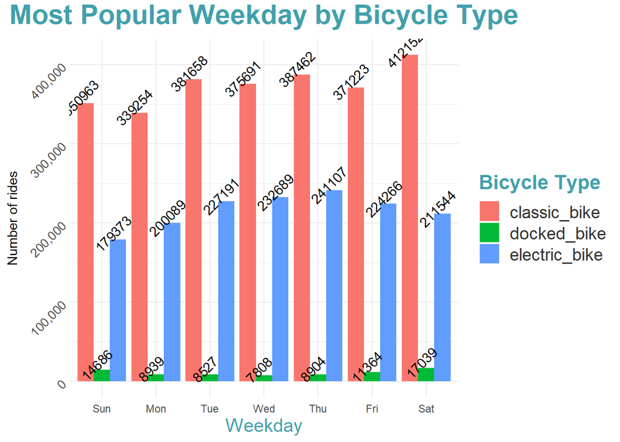

```r
ggplot(bicycle_trip_popular_days, aes(x = `Weekday`, y = `Number of rides`, fill = `Bicycle Type`)) +
  geom_col(position = "dodge") +
  geom_text(aes(label = `Number of rides`), position = position_dodge(width = 0.9), vjust = -0.25, angle = 45)+
  scale_y_continuous(labels = scales::comma) +
  labs(x = "Weekday", y = "Number of rides", fill = "Bicycle Type", title = "Most Popular Weekday by Bicycle Type") +

theme_minimal() +
  theme(
    axis.text.y = element_text(angle = 45, hjust = 1, size = 10),
    plot.title = element_text(size = 22, color = "#42a0ab",hjust = 0.5, vjust = 1.5, face = "bold"),
    plot.subtitle = element_text(size = 12, color = "grey20",hjust = 0.5, vjust = 1.5, face = "bold"),
    plot.caption = element_text(size = 8, color = "grey35"),
    legend.title = element_text(size = 16, face = "bold", color = "#42a0ab"),
    legend.text = element_text(size = 14, color = "grey20"),
    axis.title.x = element_text(size = 15, color = "#42a0ab")
  )
```

# Act

### Questions and Recommendations:

#### 2. Why would casual riders buy Cyclistic annual memberships?

- While the provided data might not comprehensively address this question, potential benefits influencing casual riders to switch to Annual Memberships could include:
  1. Unlimited rides within a 24-hour period.
  2. Discounted ride rates based on peak periods such as months, days, or specific times of the day.

#### 3. How can Cyclistic use digital media to influence casual riders to become members?

1. **Digital Surveys:** Implement surveys at the end of each ride to gather qualitative data on bicycle choices and trip purposes. Offer casual riders a glimpse of potential savings with an Annual Membership and provide a discount code for their initial year.
2. **Targeted Digital Media Campaigns:** Leverage insights from the analysis, focusing on peak periods for casual riders. Offer discounted Annual Memberships during these peak periods to attract attention and encourage the switch.
3. **Referral Campaigns:** Target existing Annual Members with referral incentives. If an existing member persuades a casual rider to switch:
   - The existing member receives a percentage discount on renewal for each converted casual rider.
   - The casual rider gets a discount on their new Annual Membership at sign-up.

These recommendations aim to capitalize on identified usage patterns and preferences, providing a strategic approach for Cyclistic to enhance user engagement and promote the transition from casual to annual memberships.